# Analysis of “ToothGrowth” Datasest from R Datasets

Brett A. Ochs

February 28, 2016

```r
library(ggplot2); library(gridExtra); library(dplyr); library(datasets); library(DT)
```

### Dataset description from datasets() package in R

The response is the length of odontoblasts (teeth) in each of 10 guinea pigs at each of three dose levels of Vitamin C (0.5, 1, and 2 mg) with each of two delivery methods (orange juice or ascorbic acid).

First we will load the dataset into a dataframe, rename columns for better understanding, and evaluate summary statistics.

```r
## Load "ToothGrowth" dataset into dataframe
df <- ToothGrowth;
## Change variable names within dataframe for better understanding and summarize
names(df) <- c("Tooth.Length", "Delivery.Method", "Dosage"); summary(df)
```

```
##   Tooth.Length   Delivery.Method     Dosage
##  Min.   : 4.20   OJ:30           Min.   :0.500
##  1st Qu.:13.07   VC:30           1st Qu.:0.500
##  Median :19.25                   Median :1.000
##  Mean   :18.81                   Mean   :1.167
##  3rd Qu.:25.27                   3rd Qu.:2.000
##  Max.   :33.90                   Max.   :2.000
```

```r
## Set up variables for dosage and delivery method.
dosages <- c(0.5, 1, 2); deliverys <- c("OJ", "VC")
```

## Exploratory Data Analysis

### Summary Table

Sometimes we may want to see a simple table with means and standard deviations for each treatment to better understand if differences may be likely. This table can be sorted and filtered to make individual comparisons to the tooth length means of that treatment, suggested to filter first by Delivery.Mechanism then by Dosage to see rows close together for Dosage.

```r
df.summary <- tbl_df(df)%>%
    group_by(Delivery.Method, Dosage) %>%
    summarise(Count = n(),
              Mean.Tooth.Length = round(mean(Tooth.Length), digits=2),
              Stdev.Tooth.Length = round(sd(Tooth.Length), digits = 2))
datatable(df.summary, rownames = FALSE, filter="top",
          caption="Table 1. Interactive summary table of different dosage and delivery mechanism statistics for Tooth Length")
```

| Delivery.Method | Dosage | Count | Mean.Tooth.Length | Stdev.Tooth.Length |
| --- | --- | --- | --- | --- |
| OJ | 0.5 | 10 | 13.23 | 4.46 |
| OJ | 1 | 10 | 22.7 | 3.91 |
| OJ | 2 | 10 | 26.06 | 2.66 |
| VC | 0.5 | 10 | 7.98 | 2.75 |
| VC | 1 | 10 | 16.77 | 2.52 |
| VC | 2 | 10 | 26.14 | 4.8 |

We see very little difference between delivery mechanisms at the highest dosage, but do see some differences of interest between delivery mechanism for both dosage or 0.5 and 1.0.

### Visuals

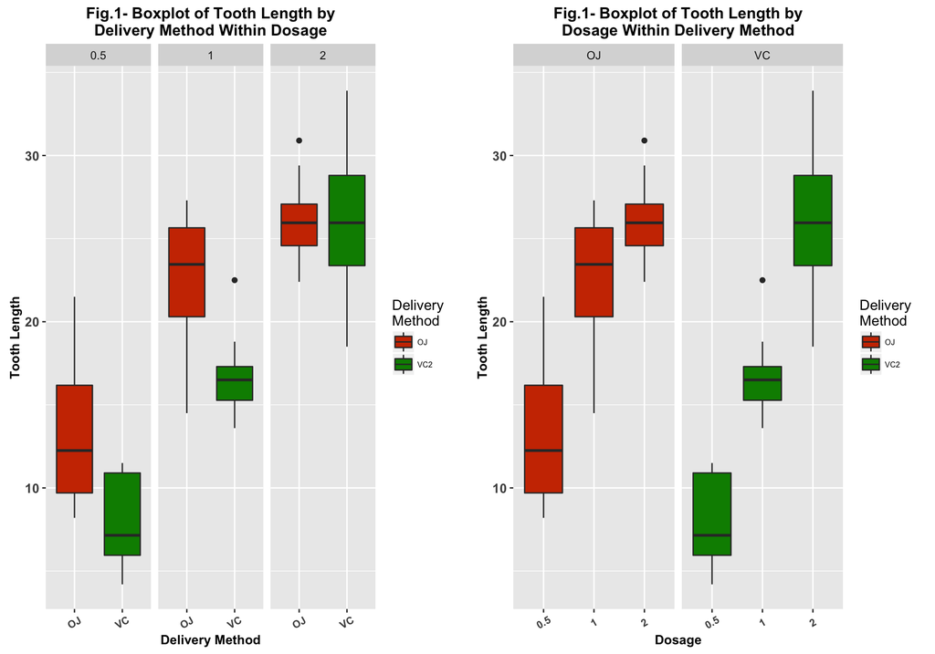

```r
## Simple boxplot to see if tooth length trends are similar across delivery methods within dosage
box1 <- ggplot(data=df) + geom_boxplot(aes(x=Delivery.Method, y=Tooth.Length, fill=Delivery.Method)) +
    scale_fill_manual(name="Delivery\nMethod", breaks=c("OJ", "VC"), labels=c("OJ", "VC2"),
                      values=c("orangered3", "green4")) +
    labs(title="Fig.1- Boxplot of Tooth Length by\nDelivery Method Within Dosage", x="Delivery Method", y="Tooth Length") +
    theme(axis.text.x=element_text(angle=30, vjust=0.5, size=8, face="bold"),
          axis.text.y=element_text(size=10, face="bold"), axis.title=element_text(size=10, face="bold"),
          plot.title=element_text(size=12, face="bold"), legend.text=element_text(size=6)) +
    facet_grid(. ~ Dosage)

## Simple boxplot to see if tooth length trends are similar across dosage within delivery methods
box2 <-ggplot(data=df) + geom_boxplot(aes(x=as.factor(Dosage), y=Tooth.Length, fill=Delivery.Method))  +
    scale_fill_manual(name="Delivery\nMethod",
                      breaks=c("OJ", "VC"),
                      labels=c("OJ", "VC2"),
                      values=c("orangered3", "green4")) +labs(title="Fig.1- Boxplot of Tooth Length by\nDosage Within Delivery Method", x="Dosage", y="Tooth Length") +
    theme(axis.text.x=element_text(angle=30, vjust=0.5, size=8, face="bold"),
          axis.text.y=element_text(size=10, face="bold"), axis.title=element_text(size=10, face="bold"),
          plot.title=element_text(size=12, face="bold"), legend.text=element_text(size=6)) +
    facet_grid(. ~ Delivery.Method)
grid.arrange(box1, box2, ncol=2)
```

## Hypothesis Testing

```r
## Evalaute differences in delivery method for teeth length across dosage
delivery.t <- t.test(Tooth.Length ~ Delivery.Method, paired=FALSE, alternative="two.sided", data=df)
delivery.t
```

```
##
##  Welch Two Sample t-test
##
## data:  Tooth.Length by Delivery.Method
## t = 1.9153, df = 55.309, p-value = 0.06063
## alternative hypothesis: true difference in means is not equal to 0
## 95 percent confidence interval:
##  -0.1710156  7.5710156
## sample estimates:
## mean in group OJ mean in group VC
##         20.66333         16.96333
```

We get a p-value of **0.0606** so we fail to reject the Null Hypothesis that the means of delivery mechanism are equal across all dosage levels. We also see the 95% confidence interval is **-0.171** to **7.571** which encompasses zero (but barely so) which also would lead us to fail to reject Null Hypothesis.

Since the p-value is close to 0.05 though we will dig in further to dosage levels and see if there are differences between delivery mechanism within individual dosage levels. Below is code and resulting t-test information for comparison of delivery mechanism within each dosage level of 0.5 mg., 1 mg., and 2 mg. Lets set up 3 Null Hypothesis to test: 1. Means of delivery mechanisms are equal for dosage **0.5 mg**. 2. Means of delivery mechanisms are equal for dosage **1 mg**. 3. Means of delivery mechanisms are equal for dosage **2 mg**.

```r
## Loop to evaluate effect of delivery method within same dosage
result <- vector("list", 6)
for(i in 1:length(dosages)){
    df.temp <- df[df$Dosage == dosages[i], ]
    t.test.temp <- t.test(Tooth.Length ~ Delivery.Method, data=df.temp)
    print(paste0("Comparison of delivery mechanism t-test of ", dosages[i], "mg dosage"))
    result[[i]] <- t.test.temp
    print(t.test.temp)
}
```

```
## [1] "Comparison of delivery mechanism t-test of 0.5mg dosage"
##
##  Welch Two Sample t-test
##
## data:  Tooth.Length by Delivery.Method
## t = 3.1697, df = 14.969, p-value = 0.006359
## alternative hypothesis: true difference in means is not equal to 0
## 95 percent confidence interval:
##  1.719057 8.780943
## sample estimates:
## mean in group OJ mean in group VC
##            13.23             7.98
##
## [1] "Comparison of delivery mechanism t-test of 1mg dosage"
##
##  Welch Two Sample t-test
##
## data:  Tooth.Length by Delivery.Method
## t = 4.0328, df = 15.358, p-value = 0.001038
## alternative hypothesis: true difference in means is not equal to 0
## 95 percent confidence interval:
##  2.802148 9.057852
## sample estimates:
## mean in group OJ mean in group VC
##            22.70            16.77
##
## [1] "Comparison of delivery mechanism t-test of 2mg dosage"
##
##  Welch Two Sample t-test
##
## data:  Tooth.Length by Delivery.Method
## t = -0.046136, df = 14.04, p-value = 0.9639
## alternative hypothesis: true difference in means is not equal to 0
## 95 percent confidence interval:
##  -3.79807  3.63807
## sample estimates:
## mean in group OJ mean in group VC
##            26.06            26.14
```

1. For dosage of **0.5 mg.** we reject the Null Hypothesis of equal delivery mechanism means since p-value of **0.00636** <= **0.05**. In this case we do see differences in Delivery Mechanism within that low dose, similar to trends within boxplots above.
2. For dosage of **1 mg.** we reject the Null Hypothesis of equal delivery mechanism means since p-value of **0.00104** <= **0.05**. In this case we do see differences in Delivery Mechanism within that middle dose, similar to trends within boxplots above.
3. For dosage of **2 mg.** we fail to reject the Null Hypothesis of equal delivery mechanism means since p-value of **0.96385** >= **0.05**. In this case we do not see differences in Delivery Mechanism within that high dose, similar to trends within boxplots above.